# Biases in Predicting Recidivism: How COMPAS Failed and Alternate Models – Team 2

#### K-means classification using priors_count and juv_other_count

> Are there discernable groups or clusters of data within the recid data set? If so, can those clusters help us discern between recividist and non-recividist observations.

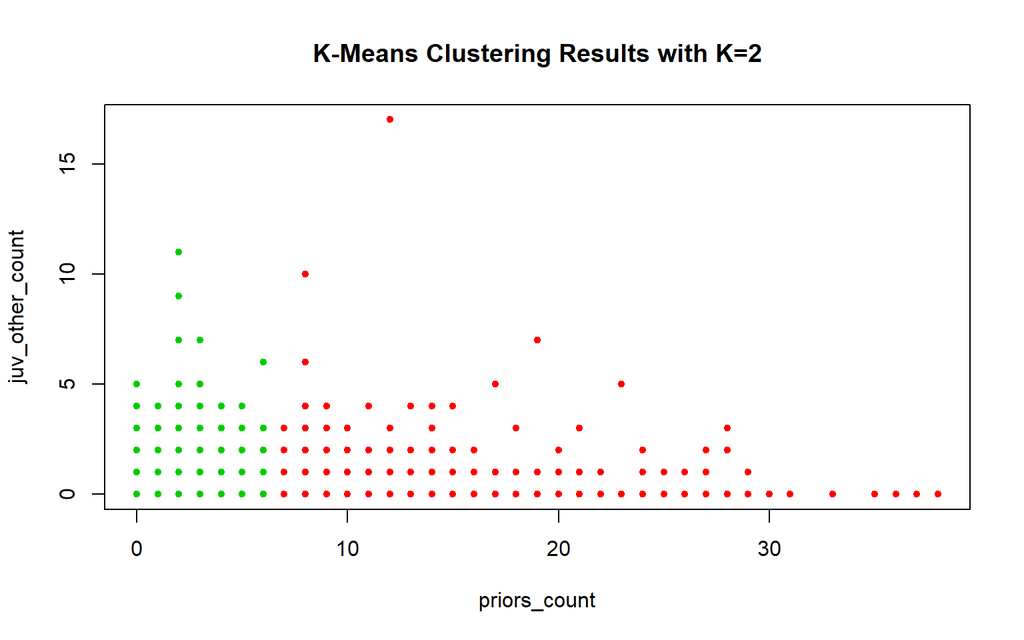

```r
# extract age and prior count and place in one data frame
kmdf <- recid$priors_count
kmdf <- as.data.frame(kmdf)
kmdf["priors_count"] <- recid$priors_count
kmdf["juv_other_count"] = recid$juv_other_count
#kmdf
kmdf <- kmdf[,-1]
#dim(kmdf)
km.out = kmeans(kmdf,2,nstart = 10)
#km.out$cluster

plot(kmdf, col =(km.out$cluster+1) , main="K-Means Clustering Results with K=2", xlab ="priors_count", ylab="juv_other_count", pch= 20, cex =1)
```

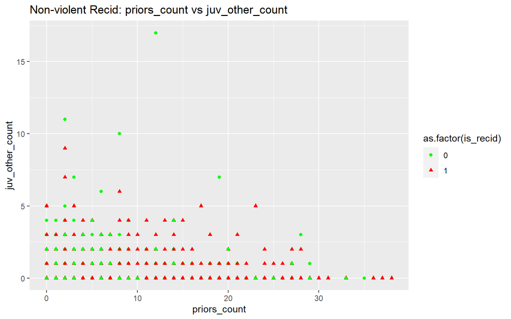

```r
ggplot(recid, aes(x = priors_count, y = juv_other_count, col = as.factor(is_recid), shape = as.factor(is_recid))) + geom_point() + scale_color_manual(values = c("green", "red"))+ ggtitle("Non-violent Recid: priors_count vs juv_other_count")
```

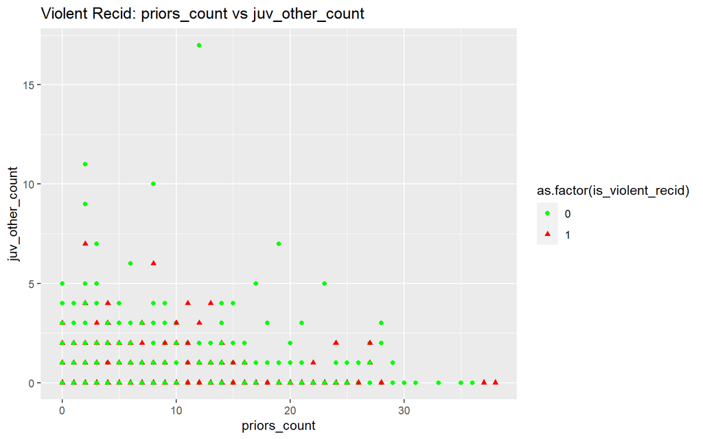

```r
#plot for violent recid
ggplot(recid, aes(x = priors_count, y = juv_other_count, col = as.factor(is_violent_recid), shape = as.factor(is_violent_recid))) + geom_point() + scale_color_manual(values = c("green", "red")) + ggtitle("Violent Recid: priors_count vs juv_other_count")
```

```r
#CLUSTERED TWO GROUPS. NEED TO STADARIZE AGE
```

#### K-means using priors_count and age

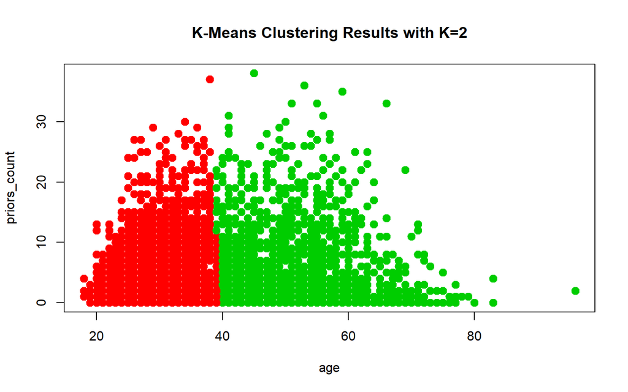

```r
# extract age and prior count and place in one data frame
kmdf <- recid$age
kmdf <- as.data.frame(kmdf)
kmdf["age"] <- recid$age
kmdf["priors_count"] = recid$priors_count
#kmdf
kmdf <- kmdf[,-1]
#kmdf.nv["is_recid"] <- nv_recid$is_recid
#dim(kmdf.nv)
km.out = kmeans(kmdf,2,nstart = 10)
#km.out$cluster

plot(kmdf, col =(km.out$cluster+1) , main="K-Means Clustering Results with K=2", xlab ="age", ylab="priors_count", pch= 20, cex =2)
```

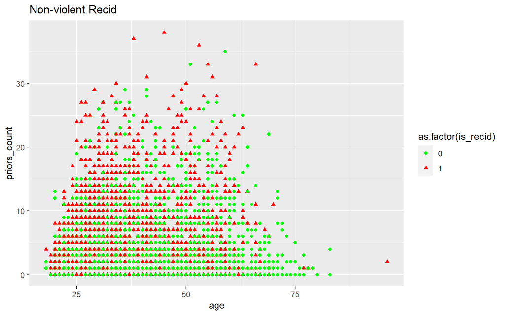

```r
ggplot(recid, aes(x = age, y = priors_count, col = as.factor(is_recid), shape = as.factor(is_recid))) + geom_point() + scale_color_manual(values = c("green", "red"))+ ggtitle("Non-violent Recid")
```

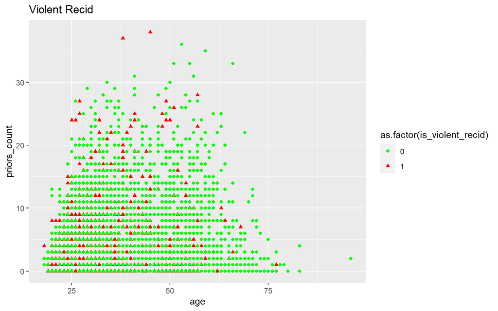

```r
#plot for violent recid
ggplot(recid, aes(x = age, y = priors_count, col = as.factor(is_violent_recid), shape = as.factor(is_violent_recid))) + geom_point() + scale_color_manual(values = c("green", "red")) + ggtitle("Violent Recid")
```

```r
#CLUSTERED TWO GROUPS. NEED TO STADARIZE AGE
```

> Using K-means methods for the violent and non-violent recividists data sets using age and prior_counts seems to be an ineffective method of identifying clusters within the data sets as the distributions of recividists and non-recividists for the variables age, and priors_count seem to overlap. On the other hand, applying K-means using priors_count and juv_other_count for non-violent recividists seems to be a good option to identify clusters of observations.

### Simple Linear Regression

```r
# Find best predictors of recividism for linear regression
regfit.violent <- regsubsets(is_violent_recid ~. -is_recid, recid, nvmax = 5)
#summary(regfit.violent)

regfit.nonviolent <- regsubsets(is_recid ~. -is_violent_recid, recid, nvmax = 5)
#summary(regfit.nonviolent)
```

> The following variables are the strongest predictors of recividism in a linear regression context: - Violent: count.prior.jail, c_charge_degree(F3), juv_misd_count - Nonviolent: count.prior.jail, age, priors_count.

> Next, we’ll produce a linear fit using the best predictors listed above for both the violent and non-violent recividist data set

```r
lmfit.nv <- lm(is_recid~count.prior.jail+age+priors_count, data = recid, subset = train)
mse.nv <- with(recid, mean((is_recid-predict(lmfit.nv,recid))[-train]^2))
mse.nv
```

```
## [1] 0.1591918
```

```r
lmfit.v <- lm(is_violent_recid~count.prior.jail + juv_misd_count, data = recid, subset = train)
mse.v <- with(recid, mean((is_violent_recid-predict(lmfit.v,recid))[-train]^2))
mse.v
```

```
## [1] 0.06472581
```

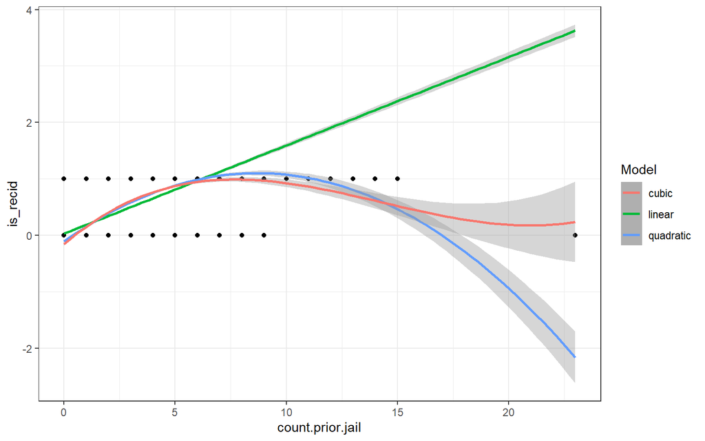

```r
#linear regression plots
qplot(data = recid, x = count.prior.jail, y = is_recid) + stat_smooth(method = "lm", aes(colour = "linear")) + stat_smooth(method = "lm", formula = y~poly(x,2), aes(colour = "quadratic")) + stat_smooth(method = "lm" , formula = y~poly(x,3), aes(colour = "cubic")) + scale_colour_discrete("Model") + theme_bw()
```

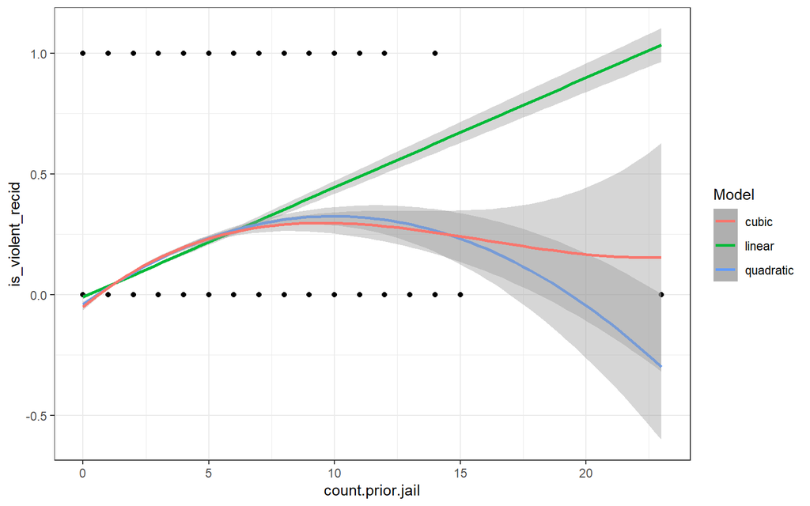

```r
qplot(data = recid, x = count.prior.jail, y = is_violent_recid) + stat_smooth(method = "lm", aes(colour = "linear")) + stat_smooth(method = "lm", formula = y~poly(x,2), aes(colour = "quadratic")) + stat_smooth(method = "lm" , formula = y~poly(x,3), aes(colour = "cubic")) + scale_colour_discrete("Model") + theme_bw()
```

#### K-fold validation

```r
#K-10 CV for non-violent recividism
cv.error10.nv <- rep(0,10)
for (i in 1:10) {
    glm.nv <- glm(is_recid~poly(count.prior.jail,i), data = recid)
    cv.error10.nv[i] <- cv.glm(recid, glm.nv, K = 10)$delta[1]
}

cv.error10.nv
```

```
##  [1]    0.1617823    0.1522842    0.1510242    0.2317933    4.1815818
##  [6]   15.0627720   76.8895228  349.8387882 3126.1044113 3261.4593437
```

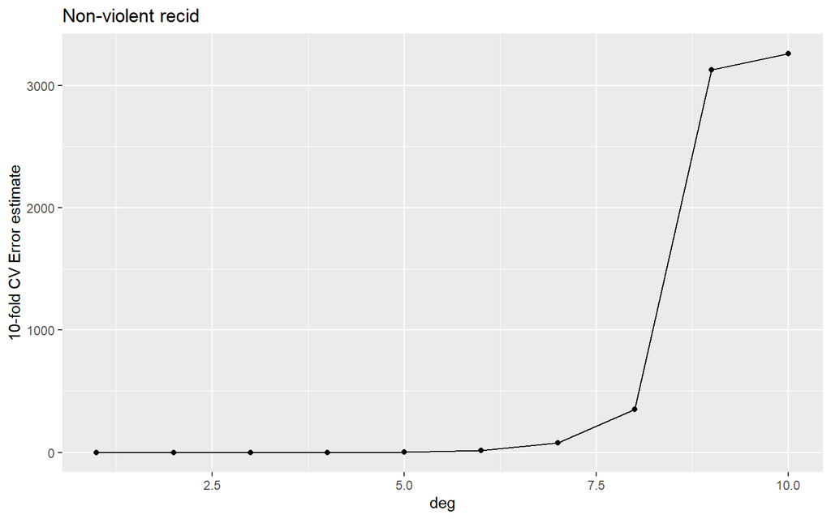

```r
cv.df10nv <- data.frame(deg=1:10, cv_error = cv.error10.nv)
qplot(data=cv.df10nv, x = deg, y = cv.error10.nv, geom = "line", ylab = "10-fold CV Error estimate", main = "Non-violent recid") + geom_point()
```

```r
which.min(cv.error10.nv)
```

```
## [1] 3
```

```r
#K-10 CV for violent recividism
cv.error10.v <- rep(0,10)
for (i in 1:10) {
    glm.v <- glm(is_violent_recid~poly(count.prior.jail,i), data = recid)
    cv.error10.v[i] <- cv.glm(recid, glm.v, K = 10)$delta[1]
}

cv.error10.v
```

```
##  [1]     0.06633744     0.06583484     0.06600587     0.07469503     0.49547235
##  [6]     0.25464351    25.16558619     0.11717836     1.96607643 78265.09530934
```

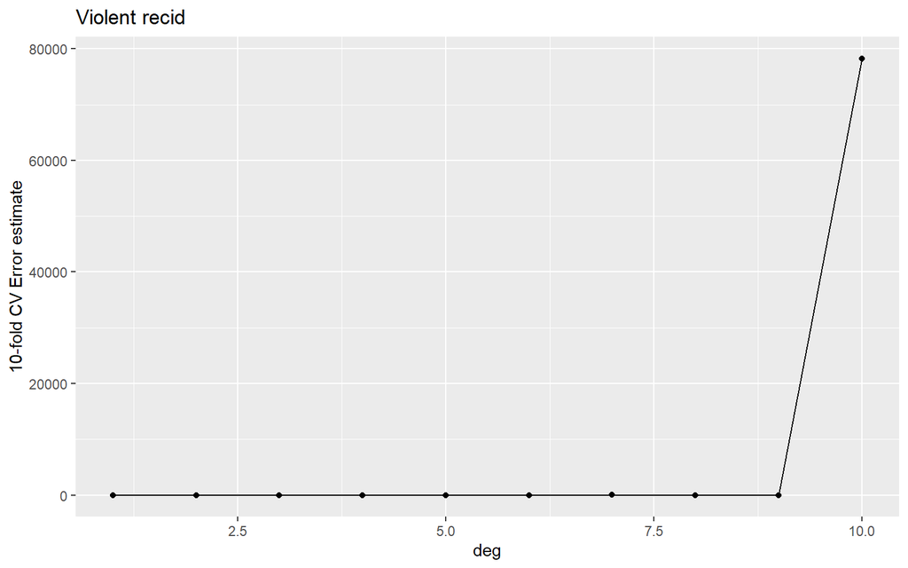

```r
cv.df10v <- data.frame(deg=1:10, cv_error = cv.error10.v)
qplot(data=cv.df10v, x = deg, y = cv.error10.v, geom = "line", ylab = "10-fold CV Error estimate", main = "Violent recid") + geom_point()
```

```r
which.min(cv.error10.v)
```

```
## [1] 2
```

### K-NN Classification

```r
#split data sets into violent and non-violent recividists (sex, race, and charge degree removed as non-numeric and thus cannot be normalized)
recid.nv <- recid[c("is_recid","age", "juv_fel_count", "juv_misd_count","juv_other_count", "priors_count","count.prior.jail","count.prior.prison","timeinjail","timeinprison")]

recid.v <- recid[c("is_violent_recid","age", "juv_fel_count", "juv_misd_count","juv_other_count", "priors_count","count.prior.jail","count.prior.prison","timeinjail","timeinprison")]

#Normalization of data
normalize <- function(x) {
    return((x-min(x))/(max(x) - min(x))) }

recid.nv.norm <- as.data.frame(lapply(recid.nv[,2:10], normalize))
recid.v.norm <- as.data.frame(lapply(recid.v[,2:10], normalize))

#create training and test data sets for non-violent recividist classification
train.nv <- recid.nv.norm[1:4911,]
test.nv <- recid.nv.norm[4912:9822,]
#create training and test data sets for violent recividists classification
train.v <- recid.v.norm[1:4911,]
test.v <- recid.v.norm[4912:9822,]

recid.nv.pred <- knn(train.nv, test.nv, recid.nv[1:4911,1], k= 90, prob = TRUE)
conf.nv <- table(recid.nv.pred, recid.nv[4912:9822,1])
conf.nv
```

```
##
## recid.nv.pred    0    1
##             0 2933  768
##             1  328  882
```

```r
tpr.nv <- (conf.nv[2,2])/(conf.nv[2,1]+conf.nv[2,2])
fpr.nv <- (conf.nv[1,2])/(conf.nv[1,1]+conf.nv[1,2])
acc.nv <- (conf.nv[2,2]+conf.nv[1,1])/(conf.nv[1,1]+conf.nv[1,2]+conf.nv[2,2]+conf.nv[2,1])
acc.nv
```

```
## [1] 0.7768275
```

```r
tpr.nv
```

```
## [1] 0.7289256
```

```r
fpr.nv
```

```
## [1] 0.2075115
```

```r
#KNN prediction for violent recividists
recid.v.pred <- knn(train.v, test.v, recid.v[1:4911,1], k= 7, prob = TRUE)
conf.v <- table(recid.v.pred, recid.v[4912:9822,1])
conf.v
```

```
##
## recid.v.pred    0    1
##            0 4481  379
##            1   37   14
```

```r
tpr.v <- (conf.v[2,2])/(conf.v[2,1]+conf.v[2,2])
fpr.v <- (conf.v[1,2])/(conf.v[1,1]+conf.v[1,2])
acc.v <- (conf.v[2,2]+conf.v[1,1])/(conf.v[1,1]+conf.v[1,2]+conf.v[2,2]+conf.v[2,1])
acc.v
```

```
## [1] 0.9152922
```

```r
tpr.v
```

```
## [1] 0.2745098
```

```r
fpr.v
```

```
## [1] 0.07798354
```

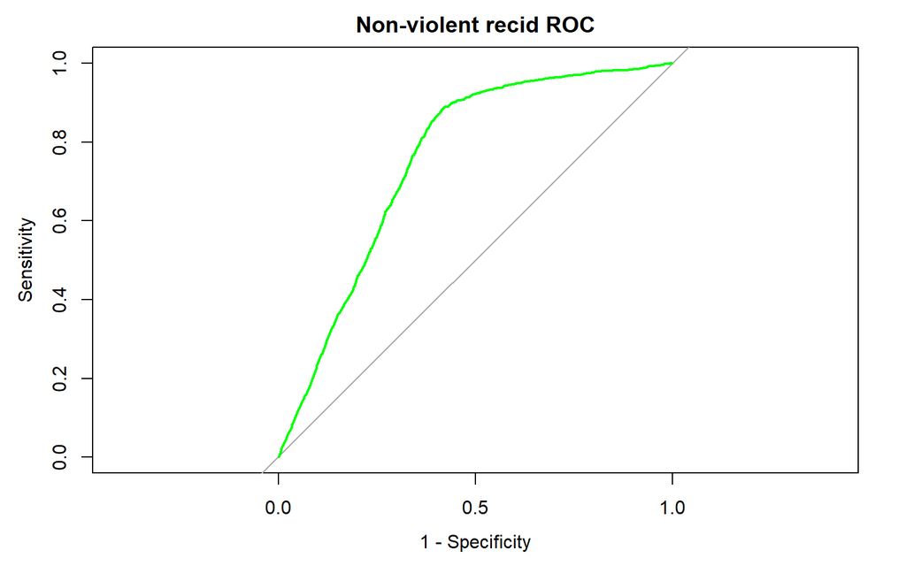

```r
##ROC CURVES
#non-violent recid
prob.nv <- attr(recid.nv.pred, "prob")
roc.nv <- roc(recid.nv[4912:9822,1], prob.nv)
plot(roc.nv, col = "green", main = "Non-violent recid ROC", legacy.axes = TRUE)
```

```r
#violent recid
prob.v <- attr(recid.v.pred, "prob")
roc.v <- roc(recid.v[4912:9822,1], prob.v)
```

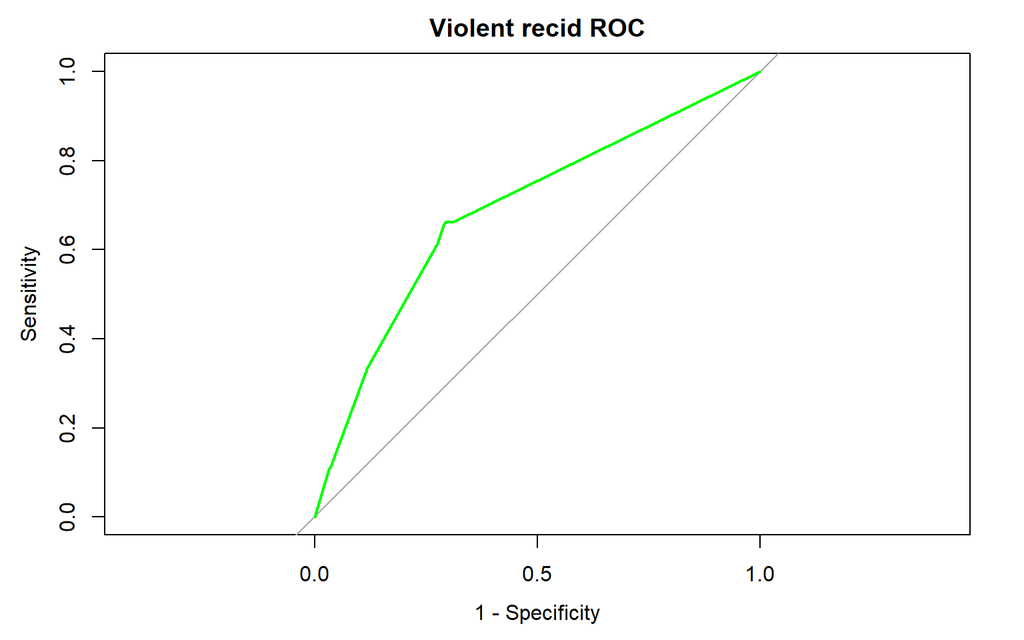

```r
plot(roc.v, col = "green", main  = "Violent recid ROC", legacy.axes = TRUE)
```

> Does the K-NN method tend to have a higher FPR for African-Americans compared to Caucasians? We perform this analysis by looking at FPRs for both group data subsets

```r
recid.nv <- recid[c("race","is_recid","age", "juv_fel_count", "juv_misd_count","juv_other_count", "priors_count","count.prior.jail","count.prior.prison","timeinjail","timeinprison")]

recid.v <- recid[c("race","is_violent_recid","age", "juv_fel_count", "juv_misd_count","juv_other_count", "priors_count","count.prior.jail","count.prior.prison","timeinjail","timeinprison")]

# Non-violent recividist classification: African-American vs. Caucasian
b.nv <- recid.nv[which(recid.nv$race == "African-American"),]
w.nv <- recid.nv[which(recid.nv$race == "Caucasian"),]

recid.nv.b <- b.nv[c("is_recid","age", "juv_fel_count", "juv_misd_count","juv_other_count", "priors_count","count.prior.jail","count.prior.prison","timeinjail","timeinprison")]

recid.nv.w <- w.nv[c("is_recid","age", "juv_fel_count", "juv_misd_count","juv_other_count", "priors_count","count.prior.jail","count.prior.prison","timeinjail","timeinprison")]

recid.nvb.norm <- as.data.frame(lapply(recid.nv.b[,2:10], normalize))
recid.nvw.norm <- as.data.frame(lapply(recid.nv.w[,2:10], normalize))

#training sets for both black and white groups
train.nvb <- recid.nvb.norm[1:2456,]
test.nvb <- recid.nvb.norm[2457:4912,]
train.nvw <- recid.nvw.norm[1:1679,]
test.nvw <- recid.nvw.norm[1680:3358,]

#KNN classification for non-violent black recividists
recid.nvb.pred <- knn(train.nvb, test.nvb, recid.nv.b[1:2456,1], k= 50)
conf.nvb <- table(recid.nvb.pred, recid.nv.b[2457:4912,1])
fpr.nvb <- (conf.nvb[1,2])/(conf.nvb[1,1]+conf.nvb[1,2])
conf.nvb
```

```
##
## recid.nvb.pred    0    1
##              0 1198  367
##              1  275  616
```

```r
fpr.nvb
```

```
## [1] 0.2345048
```

```r
#KNN classification for non-violent white recividists
recid.nvw.pred <- knn(train.nvw, test.nvw, recid.nv.w[1:1679,1], k= 50)
conf.nvw <- table(recid.nvw.pred, recid.nv.w[1680:3358,1])
conf.nvw
```

```
##
## recid.nvw.pred    0    1
##              0 1161  298
##              1   47  173
```

```r
fpr.nvw <- (conf.nvw[1,2])/(conf.nvw[1,1]+conf.nvw[1,2])
fpr.nvw
```

```
## [1] 0.2042495
```

```r
## Violent recividist classification: African-American vs. Caucasian
# Obtain data subsets for violent recividists for both groups
b.v <- recid.v[which(recid.v$race == "African-American"),]
w.v <- recid.v[which(recid.v$race == "Caucasian"),]

recid.v.b <- b.v[c("is_violent_recid","age", "juv_fel_count", "juv_misd_count","juv_other_count", "priors_count","count.prior.jail","count.prior.prison","timeinjail","timeinprison")]

recid.v.w <- w.v[c("is_violent_recid","age", "juv_fel_count", "juv_misd_count","juv_other_count", "priors_count","count.prior.jail","count.prior.prison","timeinjail","timeinprison")]

#normalize data sets for violent recid for both white and black groups
recid.vb.norm <- as.data.frame(lapply(recid.v.b[,2:10], normalize))
recid.vw.norm <- as.data.frame(lapply(recid.v.w[,2:10], normalize))

#obtain training and test datasets for both groups
train.vb <- recid.vb.norm[1:2456,]
test.vb <- recid.vb.norm[2457:4913,]
train.vw <- recid.vw.norm[1:1679,]
test.vw <- recid.vw.norm[1680:3358,]

#KNN prediction model for violent black
recid.vb.pred <- knn(train.vb, test.vb, recid.v.b[1:2456,1], k= 12)
conf.vb <- table(recid.vb.pred, recid.v.b[2457:4913,1])
fpr.vb <- (conf.vb[1,2])/(conf.vb[1,1]+conf.vb[1,2])
conf.vb
```

```
##
## recid.vb.pred    0    1
##             0 2204  247
##             1    4    2
```

```r
fpr.vb
```

```
## [1] 0.1007752
```

```r
#KNN prediction model for violent white
recid.vw.pred <- knn(train.vw, test.vw, recid.v.w[1:1679,1], k= 12)
conf.vw <- table(recid.vw.pred, recid.v.w[1680:3358,1])
conf.vw
```

```
##
## recid.vw.pred    0    1
##             0 1581   97
##             1    1    0
```

```r
fpr.vw <- (conf.vw[1,2])/(conf.vw[1,1]+conf.vw[1,2])
fpr.vw
```

```
## [1] 0.05780691
```

### Findings and Summary

**K-means Clustering**

Principal component analysis (PCA) reveals the principal components of variance in the data set to be as follows: PC1 = priors_count PC2 = juv_other_count and PC3 = age. I apply these variables in the K-means method to explore whether we can find discernable groups of clusters in the data that might be in line with differences between recividists and non-recividist. The main findings under this method are:

**Simple Linear Regression**

I begin by using the regsubsets fuction to find the best 5 predictors of both violent and non-violent recividism. The output reveals strongest predictors by group as follows:

> Violent: count.prior.jail, c_charge_degree(F3), juv_misd_count Nonviolent: count.prior.jail, age, priors_count.

Next, a linear regression is performed using the variables specified above for the non-violent and violent reciviist data sets. The model is trained using a random subset of the data and is tested on the unseen observations. Two plots are shown in the output for the strongest predictor of recividism (count.prior.jail) in linear, quadratic and cubed form.

**K-NN Classification**

For this method, I begin by, again, splitting the data set into violent and non-violent recividists. Since the K-NN method required normalization of all observations, all non-numeric variables are removed from the data sets, which include: sex, race, and charge degree. All observations are normalized once the data modifications listed above are performed.

I continue to use K-NN to answer the following question: Does the K-NN method tend to have a higher FPR for African-Americans compared to Caucasians? In other words, is the model biased?

**Was the Model Biased?**

Both the linear and K-NN methods predict or classify African-American individuals as recividists at a higher rate than Caucasians. I believe this is due to the fact that the proportion of African-American recividists (both violent and non-violent) are higher than any other group in the data set. Even when not using race as a predictor, the models seem to classify or predict recividism at a higher rate for African-Americans.

For K-NN classification, I attempt to analyze bias in a different way. Instead of looking at the proportion of individuals classified as likely to be revividists, I use the false positive rate to see if African-Americans are being misclassified as recividists at a higher rate than Caucasians. I do this by dividing the non-violent and violent recividist data sets by race group (African-Americans and Caucasians). The data is then put through the same process of normalization and the K-NN method is applied. The result is 4 confusion matrices:

[figure not shown]

Back to top

# Model Selection

Based on all of our models we selected the QDA for our model of choice. It had the lowest misclassification rates out of all of all of the models that we decided to explore, at misclassification rates of roughly 8% for Two-Year Recidivism (compared to the average of 18 - 20%), and about 4% for Violent Recidivism (compared to the average of 7 - 8%). Again, we decided to go with the lowest misclassification rate, because we believed that COMPAS had an accuracy problem – the COMPAS algorithm was faced with misclassifying Black defendants more-so than White defendants. Our QDA model is also not necessarily biased by groups:

**Two-Year-Recidivism Bias**:

We see that, even after removing African Americans from the dataset and running an ANOVA, that the differences are still statistically significant at the .05 level. This means that, visually, White offenders would be the next highest difference compared to other races. We take this to mean that the QDA model predicted Two Year Recidivism Rates unbiased across racial groups. In other words, it is correctly capturing the trends we see in the Two Year Recidivism EDA.

The QDA also predicts younger people as recidivating more than older people, as well as males more than females. This accurately captures the trends we saw in the Two Year Recidivism EDA.

**Violent Recidivism Bias**:

Similarly, we see that after removing African Americans from the dataset and running an ANOVA on Violent Recidivism, significant differences do exist. Again, we take this to mean that the QDA model predicted Violent Recidivism Rates unbiased across racial groups. In other words, QDA is correctly capturing the trends that we saw in Violent Recidivism EDA.

Younger people are also predicted to violently recidivate more than older people, as with males more than females. We believe that the QDA model accurately captures the trends we observed in the Violent Recidivism EDA.

Further, in order to accurately compare our model with the COMPAS predictive accuracy, we needed to calculate the concordance rate. This is because the cox model used by Northpointe calculates predictive accuracy via concordance. What follows is our calculation for both Two Year Recidivism and Violent Recidivism.

## Concordance for Comparison with COMPAS

```r
#Is_Recid
qda.pred.is_recid <- as.numeric(qda.pred.is_recid)
qda.recid.conc <- Concordance(qda.test.data.r, qda.pred.is_recid)

qda.recid.conc
```

```
## $Concordance
## [1] 0.4043621
##
## $Discordance
## [1] 0.5956379
##
## $Tied
## [1] 0
##
## $Pairs
## [1] 1962736
```

> According to Angwin and colleagues (2016), Northpointe quoted a concordance rate of 68%, but in ProPublica’s analysis, they were only able to achieve a 63% concordance rate. Unfortunately, our concordance rate for Two Year Recidivism is only 40.4% concordance, a 40.59% decrease.

```r
#Is_Violent_Recid
qda.pred.vis_recid<- as.numeric(qda.pred.vis_recid)
qda.vrecid.conc <- Concordance(qda.test.data.v, qda.pred.vis_recid)

qda.vrecid.conc
```

```
## $Concordance
## [1] 0.1903233
##
## $Discordance
## [1] 0.8096767
##
## $Tied
## [1] 0
##
## $Pairs
## [1] 656772
```

> Angwin and colleagues (2016) also found a concordance rate of about 65.1% for Violent Recidivism. However, the QDA model was only able to achieve 19.03% concordance, a 70.77% decrease.

In the end, our model was indeed not as accurate as Northpointe’s cox model in both Two Year and Violent Recidivism.

## Important Predictors for Two-Year and Violent Recidivism Rates

In terms of importance, we believed that the Random Forest importance plots would show us the most important predictors for both the two year and violent recidivism rates. These specific plots can be found here and here in the document, respectively. We found that:

1.`count.prior.jail` was the most important predictor of Two-Year Recidivism rates AND 2. `count.prior.jail` was also the most important predictor of Violent Recidivism rates

Both of these variables are described as the ‘number of times defendant was booked in jail’ and shows the importance that the more arrests that an individual has, the more likely the person is to recidivate, and this is intuitive.

**How do these compare?** The `count.prior.jail` is the most important variable compared to both cases. However, the MeanDecreaseAccuracy for `is_recid`’s `count.prior.jail` is close to 200 compared to 40 for `is_violent_recid`. This suggests the `is_recid` Random Forest model highly depend on the `count.prior.jail` variable. In contrast, `is_violent_recid` Random Forest model give more importance to other 6 variables.

## Comparing Classifications to COMPAS

Unfortunately, the QDA model doesn’t easily output coefficients for us to compare to the COMPAS model. We also don’t have the *exact* Northpointe COMPAS model and their classifications to compare. However, looking at the predicted graphs here, we can easily see that the QDA predicts African-Americans as recidivating (and violently recidivating) more than White defendants. Angwin and colleagues (2016) found the same issues in the COMPAS model, for both two-year recidivism and violent recidivism. As such, we do not have any *huge* systematic differences between our chosen model and the COMPAS model because they produce similar classifications for the same race, sex, and age groups.

# Discussion

## Data Limitations

In terms of the limitations of the data in terms of the bias problem, we wanted to bring to attention the fact that the data would be considered ‘biased’. We found in our EDA that African-Americans, younger people, and males all tend to recidivate more. Angwin and colleagues used Northpointe’s COMPAS scores to determine if COMPAS itself was biased. Northpointe would use these scores and plug them into a cox model to predict recidivism. It’s clear that using the score could lead to bias. However, even without using the COMPAS score included in the data set, we can see that young African-American males will typically recidivate more. A model trained on this data will train itself to capture the trends it sees in the data. If the data appear this way, it can make our models appear biased racially, and also could be considered biased by sex.

If a model is trained on this type of data, the model will be considered biased. However, we want to consider that all models trained on similar data will typically be considered bias, because of a systematic bias. Take for example a project that John worked on in undergrad (Lloyd et al. 2017). We found that White participants held an innate bias against Black targets, such that White participants initially believed that Black targets were telling lies more often than Whites. Applied to the criminal justice system, it is more than likely that African-Americans are arrested more because of an innate, systematic bias against Blacks. In all actuality, Black defendants may be no more likely to recidivate than their White counterparts, but the justice system holds the capability to skew the data so that this is no longer the case. Models fit on data collected by the justice system (such as the data used in this project and in ProPublica’s dataset) will reasonably be expected to be biased.

Although our models were thus considered to be biased, the group believes QDA, with its low misclassification rates, stands the best chance to capture the trends in similar recidivism data.

## Model Limitations

Our model did not stand a chance against the cox model that Northpointe produced. Unfortunately, this may be due to the fact that we did not create our own evaluation metric such as Northpointe, but rather created a model based on the provided data. There are many different models and Data Mining methods that we did not use in this project, especially a cox model. It is entirely possible that QDA is not the best model to predict recidivism, but perhaps a cox model *is* the best for this type of data and prediction. We decided to focus on the specific Data Mining methods we have learned in class, with the exception of the Neural Network, to showcase what we have learned over the mini. Unfortunately, a cox model is something that we did not learn (or might have touched on briefly), so such a model was not included in our analysis and discussion.

# Conclusion

We undertook 8 different classification models in the task of classifying a specific dataset of individuals on whether or not they are predicted to recidivate after two years and also if they were predicted to violently recidivate. The COMPAS model has a misclassification problem – Black defendants were more likely to be classified to recidivate than White defendants. We worked to narrow this misclassification problem, and found that QDA had the smallest misclassification rates for both two-year and violent recidivism at 8% and 4%, respectively. However, as all of us found in our personal analyses, the QDA model did suffer from bias – it predicted Black defendants as recidivating more than White defendants, males more than females, and younger individuals than older individuals. However, we discuss that perhaps such biases are not a fault of the models, but an issue in the systematic bias that may be present in the justice system’s dataset. Despite this, we believe that the QDA models best captured the trends that we observed in the datset, and we believe that QDA might be the best for predicting trends in recidivism rates.

# Citations

1. Angwin, Julia, Jeff Larson, Surya Mattu, Lauren Kirchner, and ProPublica. “Machine Bias.” ProPublica, May 23, 2016. https://www.propublica.org/article/machine-bias-risk-assessments-in-criminal-sentencing.
2. Logan, Brent. “ROC Curves and the C Statistic” 19, no. 4 (2013): 5.
3. Peter Flom and David Cassell, “Stopping Stepwise: Why Stepwise and Similar Selection Methods Are Bad, and What You Should Use” (Paper, March 23, 2013), https://web.archive.org/web/20130323174011/http://www.nesug.org/proceedings/nesug07/sa/sa07.pdf.
4. Pan, Yuqing, Qing Mai, and Xin Zhang. “TULIP: A Toolbox for Linear Discriminant Analysis with Penalties.” ArXiv:1904.03469 [Stat], April 6, 2019. http://arxiv.org/abs/1904.03469.
5. “Classification: LDA and QDA Approaches.” Accessed May 12, 2020. https://pages.mtu.edu/~shanem/psy5220/daily/Day12/classification.html.
6. Glass Box. “Best Use of Train/Val/Test Splits, with Tips for Medical Data,” September 15, 2019. https://glassboxmedicine.com/2019/09/15/best-use-of-train-val-test-splits-with-tips-for-medical-data/.
7. E. Paige Lloyd et al., “Black and White Lies: Race-Based Biases in Deception Judgments,” Psychological Science 28, no. 8 (August 1, 2017): 1125–36, https://doi.org/10.1177/0956797617705399.

Back to top